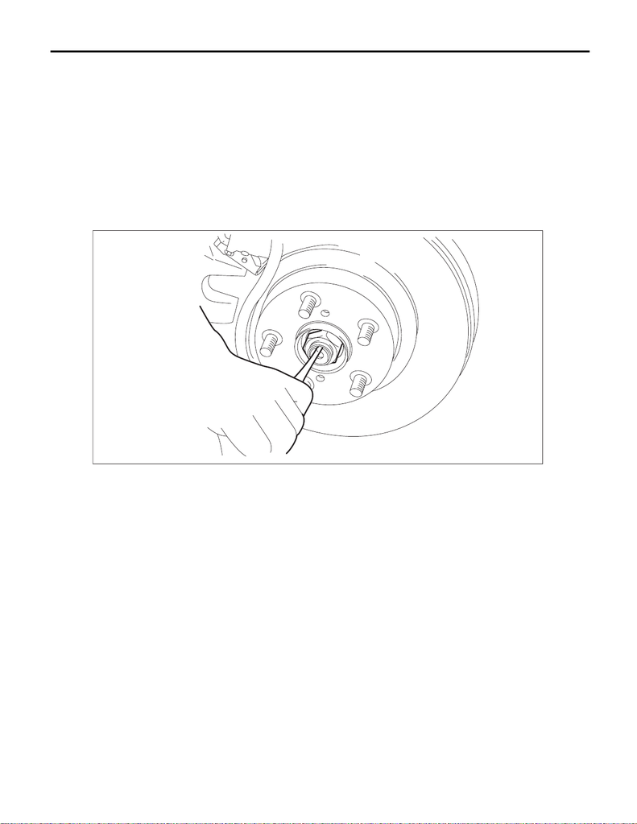

DS-32

Rear Axle

DRIVE SHAFT SYSTEM

5. Rear Axle

A: REMOVAL

1) Disconnect the ground cable from battery. <Ref. to NT-5, BATTERY, NOTE, Note.>

NOTE:

For models other than STI model, disconnect the ground terminal from battery sensor.

2) Lift up the vehicle, and then remove the rear wheels.

3) Remove the nut - axle.

CAUTION:

Do not loosen the nut - axle while the rear axle is loaded. Doing so may damage the hub unit COMPL.

(1) Lift the crimped section of the nut - axle.

(2) Remove the nut - axle using a socket wrench while depressing the brake pedal.

4) Remove the sensor assembly - headlight beam leveler. (Model with auto headlight beam leveler) <Ref. to

LI-74, REMOVAL, Rear Height Sensor.>

DS-00486

15WRX_STI_US_EN.book 32 ページ ２０１５年２月１３日 金曜日 午前１１時２０分

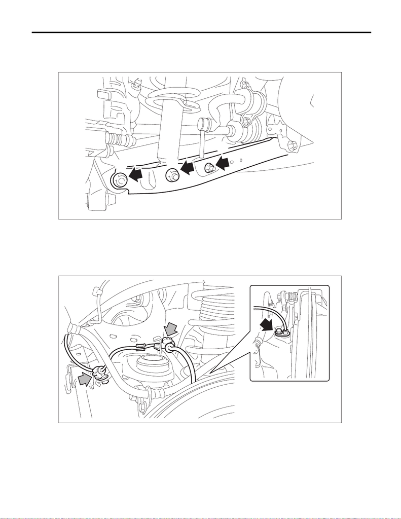

DS-33

Rear Axle

DRIVE SHAFT SYSTEM

5) Remove the bolts and nuts, and lower the lateral link assembly - rear.

(1) Remove the nut and disconnect the rear stabilizer link assembly.

(2) Remove the bolts from the lower side of rear shock absorber assembly.

(3) Disconnect the housing assembly - rear axle from the lateral link assembly - rear.

6) Remove the rear ABS wheel speed sensor from the housing assembly - rear axle.

(1) Remove the bolts, and remove the ABS wheel speed sensor.

(2) Remove the rear ABS wheel speed sensor harness from the upper arm.

CAUTION:

• Be careful not to damage the sensor.

• Do not apply excessive force to the sensor harness.

RS-00402

(1)

(2)

(3)

RS-00414

15WRX_STI_US_EN.book 33 ページ ２０１５年２月１３日 金曜日 午前１１時２０分

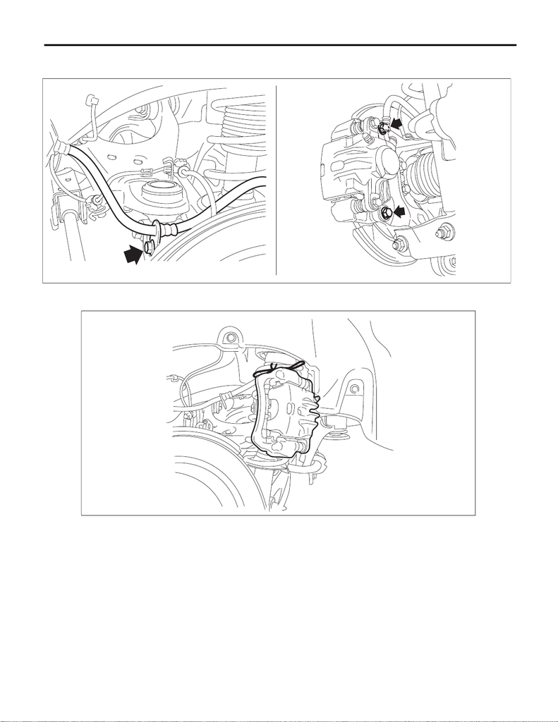

DS-34

Rear Axle

DRIVE SHAFT SYSTEM

7) Remove the disc brake assembly.

(1) Remove the bolts and then remove the brake hose bracket and disc brake assembly.

(2) Prepare wiring harnesses etc. to be discarded, and suspend the disc brake assembly from the shock

absorber assembly.

8) Remove the rear disc rotor. <Ref. to BR-39, REMOVAL, Rear Disc Rotor.>

9) Remove the rear drive shaft assembly. <Ref. to DS-64, REMOVAL, Rear Drive Shaft.>

BR-00988

RS-00404

15WRX_STI_US_EN.book 34 ページ ２０１５年２月１３日 金曜日 午前１１時２０分

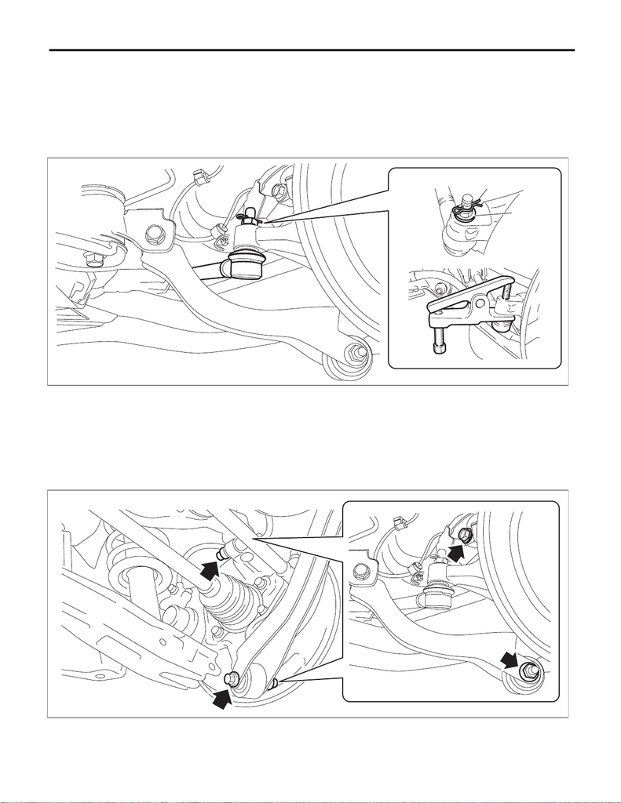

DS-35

Rear Axle

DRIVE SHAFT SYSTEM

10) Remove the lateral link assembly - front.

(1) Remove the snap pin (a) and nut (b).

(2) Remove the ball joint from the housing assembly - rear axle.

CAUTION:

Be careful not to damage the boot of the joint.

Preparation tool:

Tie-rod ball joint puller

11) Remove the housing assembly - rear axle.

CAUTION:

• Be careful of the weight of the housing assembly - rear axle.

• Be careful not to damage the spline portion of the drive shaft.

(1) Remove the bolts, and disconnect the upper arm, trailing link and lateral link assembly - rear.

CAUTION:

Be careful not to damage the boot of the joint.

(2) Remove the housing assembly - rear axle.

12) Refer to “Rear Hub Unit Bearing” for removal of the hub unit COMPL - rear axle. <Ref. to DS-40, RE-

MOVAL, Rear Hub Unit Bearing.>

DS-00570

(b)

(a)

DS-00571

15WRX_STI_US_EN.book 35 ページ ２０１５年２月１３日 金曜日 午前１１時２０分

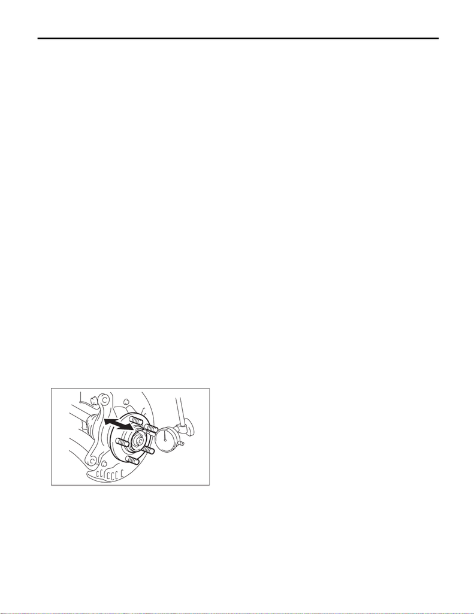

DS-36

Rear Axle

DRIVE SHAFT SYSTEM

B: INSTALLATION

1) Temporarily tighten the housing assembly - rear axle to the upper arm assembly.

2) Install the rear drive shaft assembly. <Ref. to DS-68, INSTALLATION, Rear Drive Shaft.>

CAUTION:

Do not hammer the drive shaft assembly when installing.

(1) Insert the drive shaft assembly into the hub spline, and pull it into the specified position.

(2) Tighten the new nut - axle temporarily.

3) Tighten the rear shock absorber assembly, rear stabilizer link assembly and other links to the specified

torque.

Tightening torque:

Rear suspension: <Ref. to RS-3, REAR SUSPENSION, COMPONENT, General Description.>

Rear shock absorber: <Ref. to RS-5, REAR SHOCK ABSORBER, COMPONENT, General Descrip-

tion.>

4) Install the rear disc rotor.

5) Install the disc brake assembly.

Tightening torque:

STI model: 65 N·m (6.6 kgf-m, 47.9 ft-lb)

Except for STI model: 66 N·m (6.7 kgf-m, 48.7 ft-lb)

6) Install the brake hose bracket and rear ABS wheel speed sensor.

Tightening torque:

Brake hose bracket: 33 N·m (3.4 kgf-m, 24.3 ft-lb)

Rear ABS wheel speed sensor: 7.5 N·m (0.8 kgf-m, 5.5 ft-lb)

7) Install the sensor assembly - headlight beam leveler. (Model with auto headlight beam leveler)

Tightening torque:

7.5 N·m (0.8 kgf-m, 5.5 ft-lb)

8) While depressing the brake pedal, tighten new nuts - axle to the specified torque.

CAUTION:

Do not load the rear axle before tightening the nut - axle. Doing so may damage the hub unit COMPL.

Tightening torque:

190 N·m (19.4 kgf-m, 140.1 ft-lb)

9) Inspect the lean of axis direction using a dial gauge. Replace the hub unit COMPL - rear axle if the play

exceeds the limit.

Service limit:

Maximum: 0.05 mm (0.0020 in)

DS-00062

15WRX_STI_US_EN.book 36 ページ ２０１５年２月１３日 金曜日 午前１１時２０分

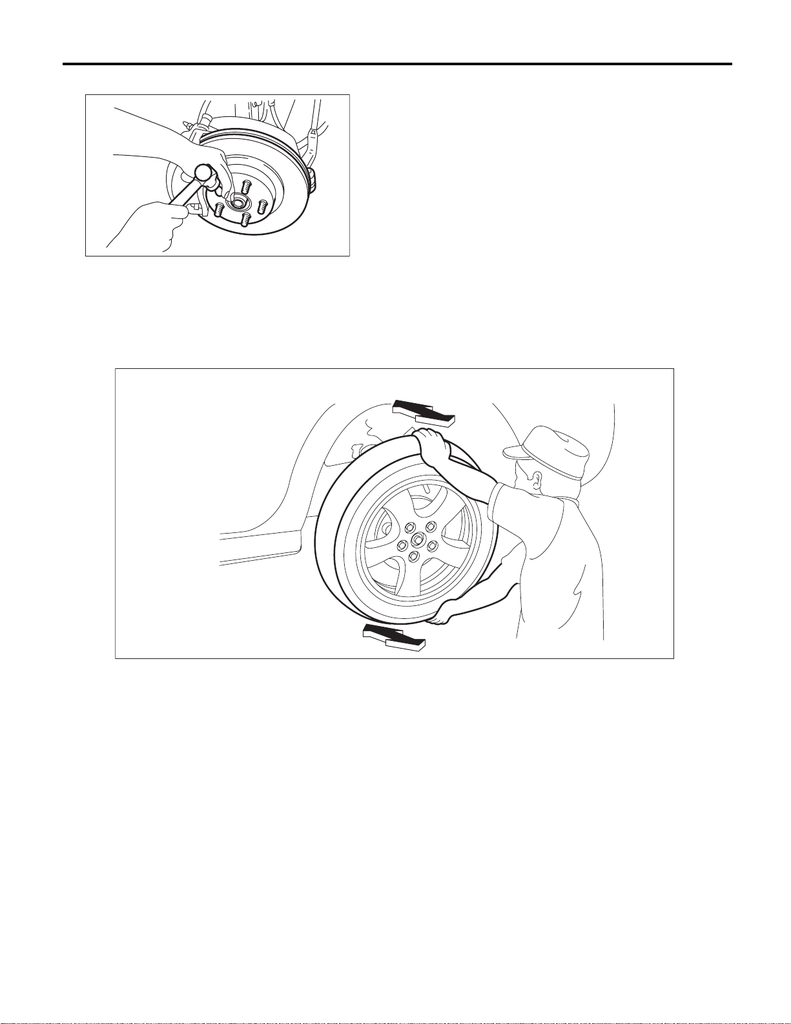

DS-37

Rear Axle

DRIVE SHAFT SYSTEM

10) After tightening the nut - axle, lock it securely.

11) Install the rear wheels, and perform the following inspections.

Tightening torque:

120 N·m (12.2 kgf-m, 88.5 ft-lb)

1. Check the wheels for smooth rotation.

2. Check that there is no play by moving the upper and lower portions of rear tire in an axial direction with the

brake pedal released.

• Play exists → Check the hub unit COMPL - rear axle. <Ref. to DS-47, INSPECTION, Rear Hub Unit

Bearing.>

12) Inspect the wheel alignment and adjust if necessary.

• Inspection: <Ref. to FS-10, INSPECTION, Wheel Alignment.>

• Adjustment: <Ref. to FS-15, ADJUSTMENT, Wheel Alignment.>

CAUTION:

When the wheel alignment has been adjusted, perform “VDC sensor midpoint setting mode” of the

VDC. <Ref. to VDC-16, ADJUSTMENT, VDC Control Module and Hydraulic Control Unit (VDCCM&H/

U).>

13) Perform reinitialization of the auto headlight beam leveler system. (Model with auto headlight beam lev-

eler) <Ref. to LI-16, PROCEDURE, Auto Headlight Beam Leveler System.>

DS-00048

DS-00609

15WRX_STI_US_EN.book 37 ページ ２０１５年２月１３日 金曜日 午前１１時２０分

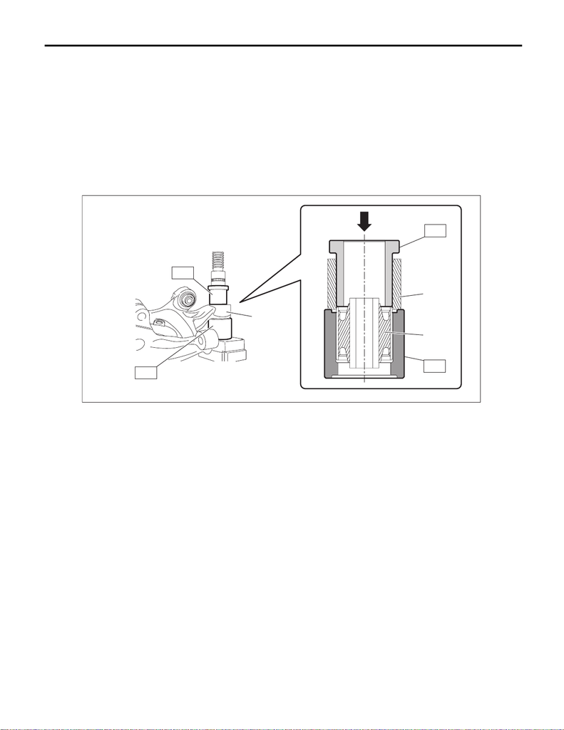

DS-38

Rear Axle

DRIVE SHAFT SYSTEM

C: DISASSEMBLY

1. BUSHING - REAR AXLE HOUSING

Do not remove the housing assembly - rear axle because the bushing - rear axle housing cannot be replaced.

If it is removed, replace the housing assembly - rear axle.

2. BUSHING - TRAILING LINK

1) Remove the housing assembly - rear axle. <Ref. to DS-32, REMOVAL, Rear Axle.>

2) Using the ST and a hydraulic press, push out the bushing.

Preparation tool:

ST1: BUSHING REMOVER (20099FG000)

ST2: INSTALLER & REMOVER (BASE) (20099PA010)

(1) Housing ASSY - rear axle (2) Bushing - trailing link

RS-00338

ST1

ST2

(1)

(2)

ST1

ST2

(1)

15WRX_STI_US_EN.book 38 ページ ２０１５年２月１３日 金曜日 午前１１時２０分

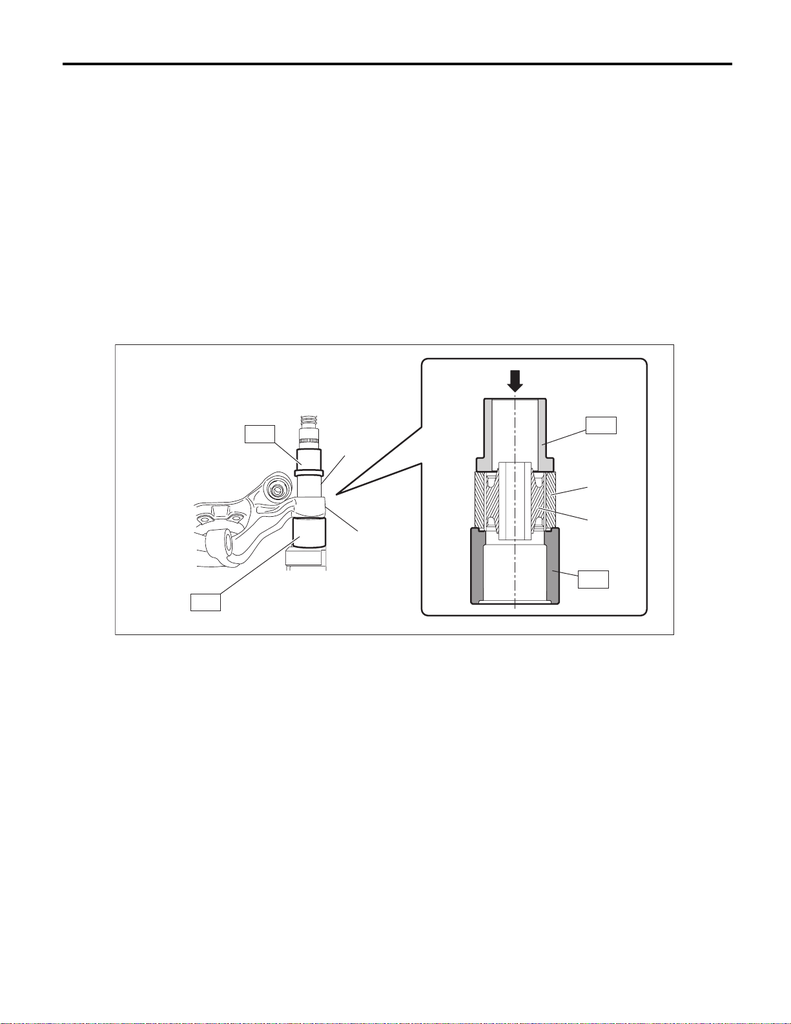

DS-39

Rear Axle

DRIVE SHAFT SYSTEM

D: ASSEMBLY

1. BUSHING - REAR AXLE HOUSING

Do not remove the housing assembly - rear axle because the bushing - rear axle housing cannot be replaced.

If it is removed, replace the housing assembly - rear axle.

2. BUSHING - TRAILING LINK

1) Before assembly, inspect the following items and replace any faulty part with a new one.

• Perform visual check for damage or bend on the trailing link.

• Visually check the bushing for abnormal cracks, fatigue or damage.

2) Press-fit the bushing using ST and the hydraulic press.

CAUTION:

Make sure to press the bushing straight in.

Preparation tool:

ST1: BUSHING REMOVER (20099FG000)

ST2: INSTALLER & REMOVER (BASE) (20099PA010)

(1) Bushing (2) Housing ASSY - rear axle

RS-00339

(1)

(2)

ST1

ST2

(1)

(2)

ST2

ST1

15WRX_STI_US_EN.book 39 ページ ２０１５年２月１３日 金曜日 午前１１時２０分